# Latihan Air Quality Index

Atha Nabilah Rosyadi

2025-09-09

# Library

```r
library(dLagM)
library(dynlm)
library(MLmetrics)
library(lmtest)
library(rio)
library (dplyr)
library(ggplot2)
library(tidyr)
library(dLagM)
library(lmtest)
library(tseries)
```

# Data

```r
df <- rio::import("https://github.com/athanabilah21/mpdw/raw/refs/heads/main/Pertemuan%203/NewDelhi_Air_quality.csv")
df
```

```
##    V1  AQI       CO      datetime        no2       o3      pm10     pm25
## 1   0 30.2 198.6027 2022-10-21:18 0.04685717 55.78995 10.486722 5.637410
## 2   1 28.2 197.6013 2022-10-21:19 0.04645554 54.93164 10.719325 4.618169
## 3   2 26.6 198.6027 2022-10-21:20 0.04685717 54.64554 11.155578 3.520902
## 4   3 25.0 201.9405 2022-10-21:21 0.04819594 55.07469 11.116206 2.225919
## 5   4 26.0 205.2784 2022-10-21:22 0.04886533 55.78995 10.405250 1.979471
## 6   5 26.0 208.6163 2022-10-21:23 0.05020411 56.50520  9.402518 1.792677
## 7   6 26.0 208.6163 2022-10-22:00 0.05020411 55.78995  8.482822 1.752237
## 8   7 24.0 205.2784 2022-10-22:01 0.05020411 52.92892  7.586667 1.858459
## 9   8 23.0 200.2716 2022-10-22:02 0.04685717 50.06790  7.636587 2.208076
## 10  9 24.0 196.9338 2022-10-22:03 0.04417961 51.49841  8.487648 2.476681
## 11 10 25.0 198.6027 2022-10-22:04 0.04284084 53.64418  9.357371 2.585729
## 12 11 26.0 200.2716 2022-10-22:05 0.04049798 55.78995 10.338728 2.390081
## 13 12 27.0 203.6095 2022-10-22:06 0.04016329 59.36623 10.523314 2.086022
## 14 13 29.0 205.2784 2022-10-22:07 0.03882451 62.22725 10.635970 1.937047
```

[output cut: 131 more lines]

```r
str(df)
```

```
## 'data.frame':    72 obs. of  12 variables:
##  $ V1             : int  0 1 2 3 4 5 6 7 8 9 ...
##  $ AQI            : num  30.2 28.2 26.6 25 26 26 26 24 23 24 ...
##  $ CO             : num  199 198 199 202 205 ...
##  $ datetime       : chr  "2022-10-21:18" "2022-10-21:19" "2022-10-21:20" "2022-10-21:21" ...
##  $ no2            : num  0.0469 0.0465 0.0469 0.0482 0.0489 ...
##  $ o3             : num  55.8 54.9 54.6 55.1 55.8 ...
##  $ pm10           : num  10.5 10.7 11.2 11.1 10.4 ...
##  $ pm25           : num  5.64 4.62 3.52 2.23 1.98 ...
##  $ so2            : num  0.387 0.41 0.402 0.376 0.339 ...
##  $ timestamp_local: POSIXct, format: "2022-10-21 23:00:00" "2022-10-22 00:00:00" ...
##  $ timestamp_utc  : POSIXct, format: "2022-10-21 18:00:00" "2022-10-21 19:00:00" ...
##  $ ts             : int  1666375200 1666378800 1666382400 1666386000 1666389600 1666393200 1666396800 1666400400 1666404000 1666407600 ...
```

# Melihat Plot

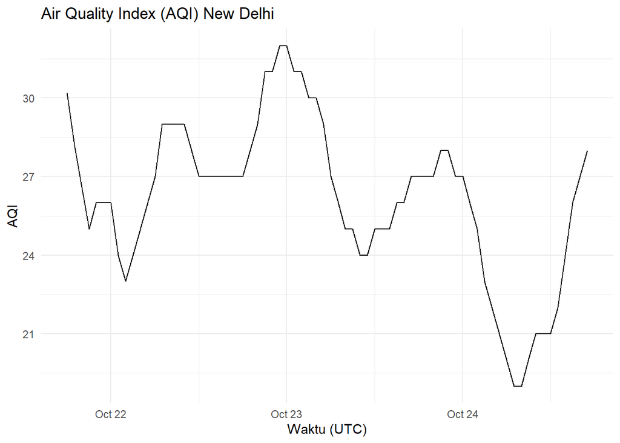

```r
ggplot(df, aes(x = timestamp_utc, y = AQI)) +
  geom_line() +
  labs(title = "Air Quality Index (AQI) New Delhi",
       x = "Waktu (UTC)", y = "AQI") +
  theme_minimal()
```

# Melihat Korelasi

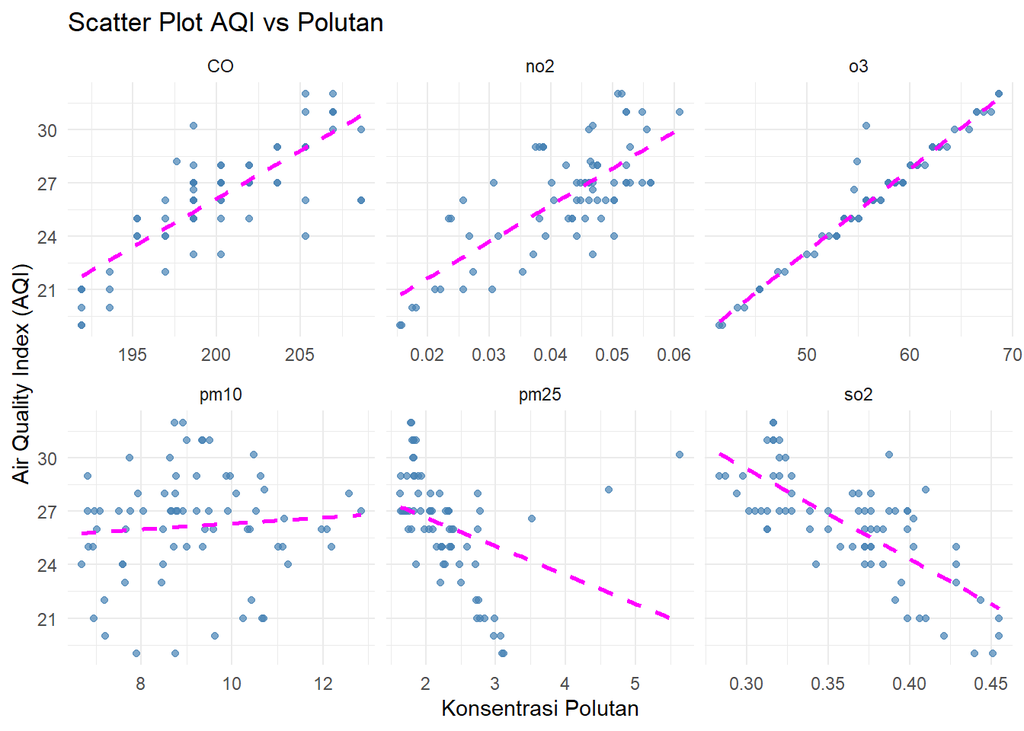

```r
vars <- c("AQI","CO","no2","o3","pm10","pm25","so2")

# ubah ke long format biar gampang difacet
df_long <- df[, vars] %>%
  pivot_longer(cols = -AQI, names_to = "Polutan", values_to = "Konsentrasi")

# scatter plot
ggplot(df_long, aes(x = Konsentrasi, y = AQI)) +
  geom_point(color = "steelblue", alpha = 0.7) +
  geom_smooth(method = "lm", se = FALSE, color = "magenta", linetype = "dashed") +
  facet_wrap(~ Polutan, scales = "free_x") +
  labs(title = "Scatter Plot AQI vs Polutan",
       x = "Konsentrasi Polutan",
       y = "Air Quality Index (AQI)") +
  theme_minimal()
```

```r
# Korelasi antar polutan dengan AQI
vars <- c("AQI","CO","no2","o3","pm10","pm25","so2")
cor_matrix <- cor(df[, vars], use="complete.obs", method="pearson")
cor_matrix["AQI", ]
```

```
##         AQI          CO         no2          o3        pm10        pm25
##  1.00000000  0.79763320  0.73765472  0.97359901  0.08257568 -0.34665524
##         so2
## -0.74247813
```

$O_3$ atau ozon memiliki korelasi positif yang lebih tinggi dibanding yang lainnya yaitu 0.97, sehingga $O_3$ akan menjadi variabel X

# Eksplorasi

## Ubah ke Time Series

```r
AQI.ts <- ts(df$AQI)
CO.ts <- ts(df$CO)
no2.ts <- ts(df$no2)
o3.ts <- ts(df$o3)
pm10.ts <- ts(df$pm10)
pm25.ts <- ts(df$pm25)
so2.ts <- ts(df$so2)
```

```r
summary(AQI.ts)
```

```
##    Min. 1st Qu.  Median    Mean 3rd Qu.    Max.
##   19.00   25.00   27.00   26.18   28.00   32.00
```

```r
summary(o3.ts)
```

```
##    Min. 1st Qu.  Median    Mean 3rd Qu.    Max.
##   41.48   53.64   57.22   56.57   60.08   68.66
```

## Plot

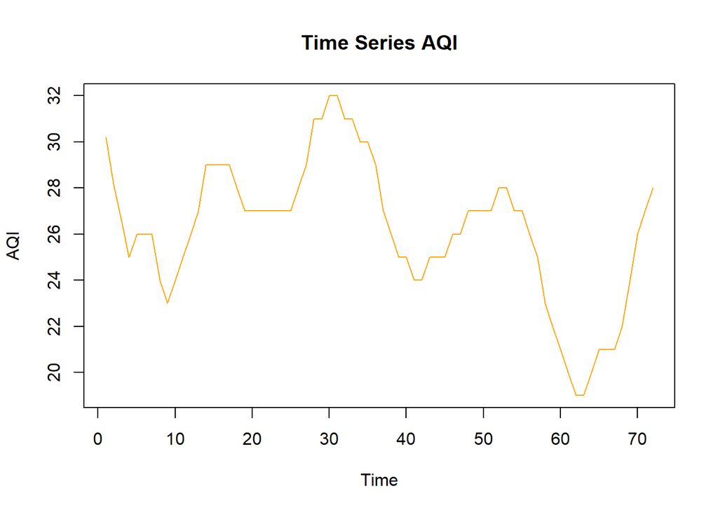

```r
plot(AQI.ts, main="Time Series AQI", ylab="AQI", xlab="Time", col="orange")
```

AQI berfluktuasi cukup tajam antara ~20–32. Ada puncak di sekitar jam ke-30 dan penurunan tajam sekitar jam ke-60. Hal ini menunjukkan kondisi kualitas udara tidak stabil dalam periode observasi.

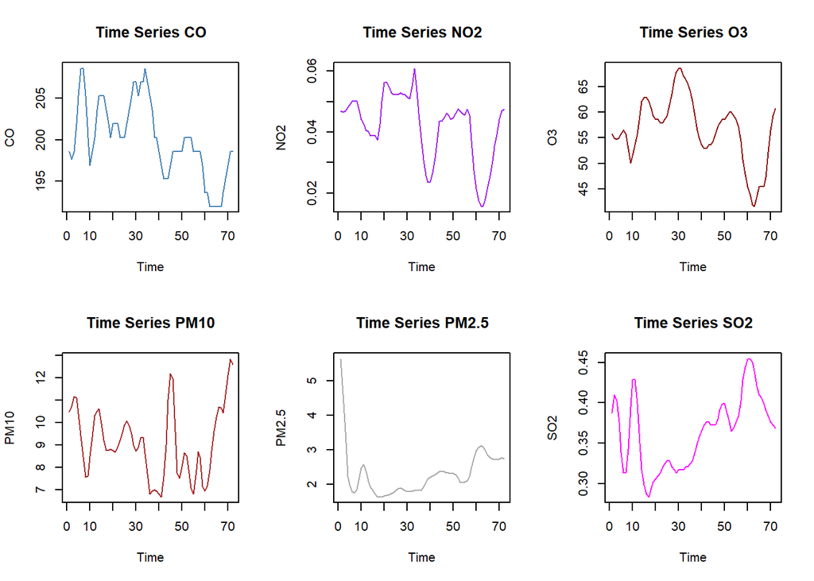

```r
par(mfrow=c(2,3))  # atur layout 3 baris 2 kolom

plot(CO.ts, main="Time Series CO", ylab="CO", xlab="Time", col="steelblue")
plot(no2.ts, main="Time Series NO2", ylab="NO2", xlab="Time", col="purple")
plot(o3.ts, main="Time Series O3", ylab="O3", xlab="Time", col="darkred")
plot(pm10.ts, main="Time Series PM10", ylab="PM10", xlab="Time", col="brown")
plot(pm25.ts, main="Time Series PM2.5", ylab="PM2.5", xlab="Time", col="darkgrey")
plot(so2.ts, main="Time Series SO2", ylab="SO2", xlab="Time", col="magenta")
```

## CCF

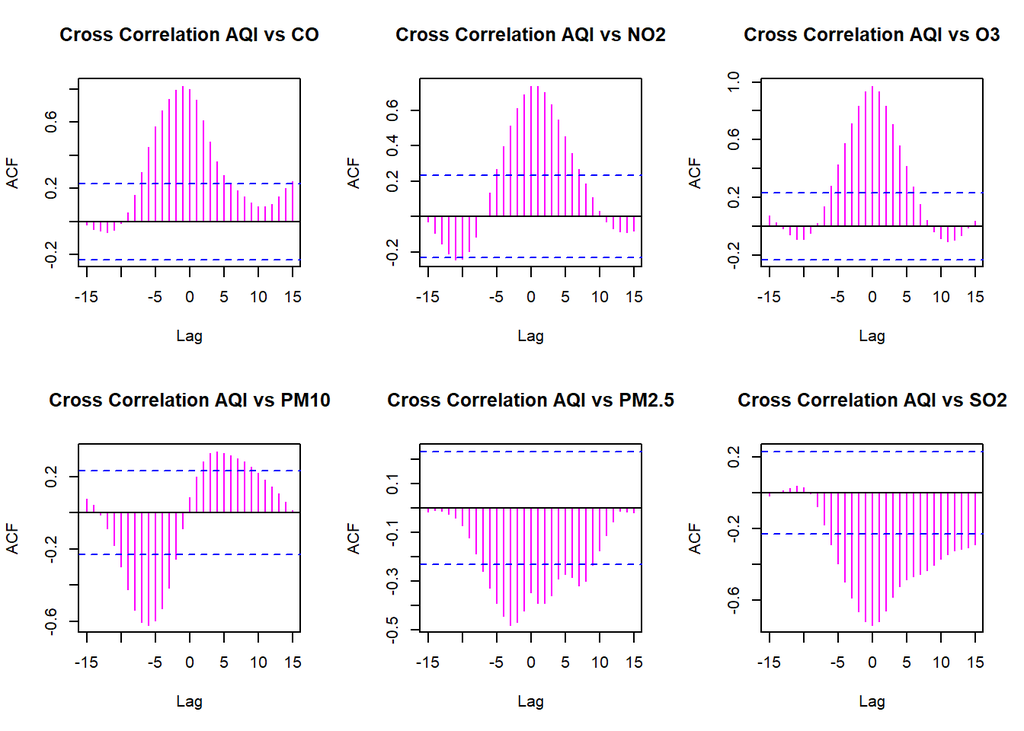

```r
par(mfrow=c(2,3))  # atur layout 3 baris 2 kolom
ccf(df$AQI, df$CO, main="Cross Correlation AQI vs CO", col="magenta")
ccf(df$AQI, df$no2, main="Cross Correlation AQI vs NO2", col="magenta")
ccf(df$AQI, df$o3, main="Cross Correlation AQI vs O3", col="magenta")
ccf(df$AQI, df$pm10, main="Cross Correlation AQI vs PM10", col="magenta")
ccf(df$AQI, df$pm25, main="Cross Correlation AQI vs PM2.5", col="magenta")
ccf(df$AQI, df$so2, main="Cross Correlation AQI vs SO2", col="magenta")
```

# Persiapan Pemodelan

```r
data <- data.frame(
  AQI = df$AQI,   # variabel dependen (Y)
  O3  = df$o3     # variabel independen (X)
)
data
```

```
##     AQI       O3
## 1  30.2 55.78995
## 2  28.2 54.93164
## 3  26.6 54.64554
## 4  25.0 55.07469
## 5  26.0 55.78995
## 6  26.0 56.50520
## 7  26.0 55.78995
## 8  24.0 52.92892
## 9  23.0 50.06790
## 10 24.0 51.49841
## 11 25.0 53.64418
## 12 26.0 55.78995
## 13 27.0 59.36623
## 14 29.0 62.22725
```

[output cut: 58 more lines]

## Pembagian Data

```r
#SPLIT DATA
n <- nrow(data)
n_train <- floor(0.8 * n)
n_test  <- n - n_train

train <- data[1:n_train, ]
test  <- data[(n_train + 1):n, ]
```

```r
train.ts<-ts(train)
test.ts<-ts(test)
data.ts<-ts(data)
```

## Diagnostik Residual

Diagnostik residu menunjukkan apakah model ARDL memenuhi asumsi OLS

```r
# fit model ARDL
model_ardl <- dLagM::ardlDlm(formula = AQI ~ O3, data = train, p = 1, q = 1)

# Residuals
resid_ardl <- residuals(model_ardl)
```

```
## Time Series:
## Start = 2
## End = 57
## Frequency = 1
##           2           3           4           5           6           7
##  0.86831267  0.11875068 -1.02613453  0.45187812 -0.18308928  0.31867622
##           8           9          10          11          12          13
## -0.47286050  0.16172824  0.29139726  0.13205800  0.13243806 -0.55127260
##          14          15          16          17          18          19
##  0.42650180 -0.18194792 -0.02222789  0.31981758 -0.15581055 -0.33851653
##          20          21          22          23          24          25
##  0.13673154 -0.02298871  0.31905676  0.15933673 -0.18270874 -0.36503466
##          26          27          28          29          30          31
## -0.23145177 -0.23107123  0.42726479 -0.52323368  0.45416203  0.16123943
##          32          33          34          35          36          37
## -0.15466963  0.32058080 -0.49709727  0.47991739  0.18661613 -0.47171866
##          38          39          40          41          42          43
##  0.16286890 -0.33927688  0.47801596 -0.49937863 -0.20645603  0.45149850
##          44          45          46          47          48          49
##  0.15857590 -0.18347005  0.29215831 -0.52513571  0.45225933 -0.18270874
##          50          51          52          53          54          55
## -0.02298871 -0.36503466  0.45263964  0.15971727 -0.49823678  0.13673154
##          56          57
## -0.33889777  0.16248859
```

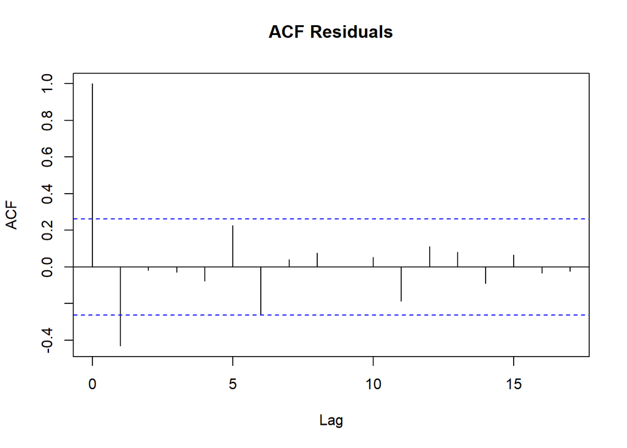

```r
## 1. Autokorelasi
acf(resid_ardl, main="ACF Residuals")                 # plot ACF
```

```r
dwtest(model_ardl$model)                              # Durbin-Watson
```

```
##
##  Durbin-Watson test
##
## data:  model_ardl$model
## DW = 2.7592, p-value = 0.9954
## alternative hypothesis: true autocorrelation is greater than 0
```

```r
bgtest(model_ardl$model, order = 5)                   # Breusch–Godfrey, lag 5
```

```
##
##  Breusch-Godfrey test for serial correlation of order up to 5
##
## data:  model_ardl$model
## LM test = 24.651, df = 5, p-value = 0.0001627
```

```r
## 2. Normalitas
shapiro.test(resid_ardl)                              # Shapiro–Wilk
```

```
##
##  Shapiro-Wilk normality test
##
## data:  resid_ardl
## W = 0.96195, p-value = 0.07469
```

```r
jarque.bera.test(resid_ardl)                          # Jarque–Bera
```

```
##
##  Jarque Bera Test
##
## data:  resid_ardl
## X-squared = 0.79475, df = 2, p-value = 0.6721
```

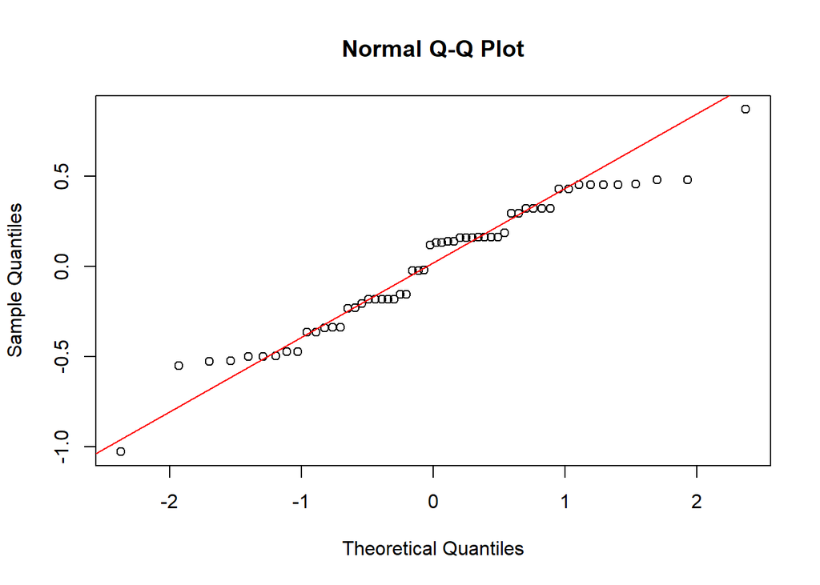

```r
qqnorm(resid_ardl); qqline(resid_ardl, col="red")     # QQ-plot
```

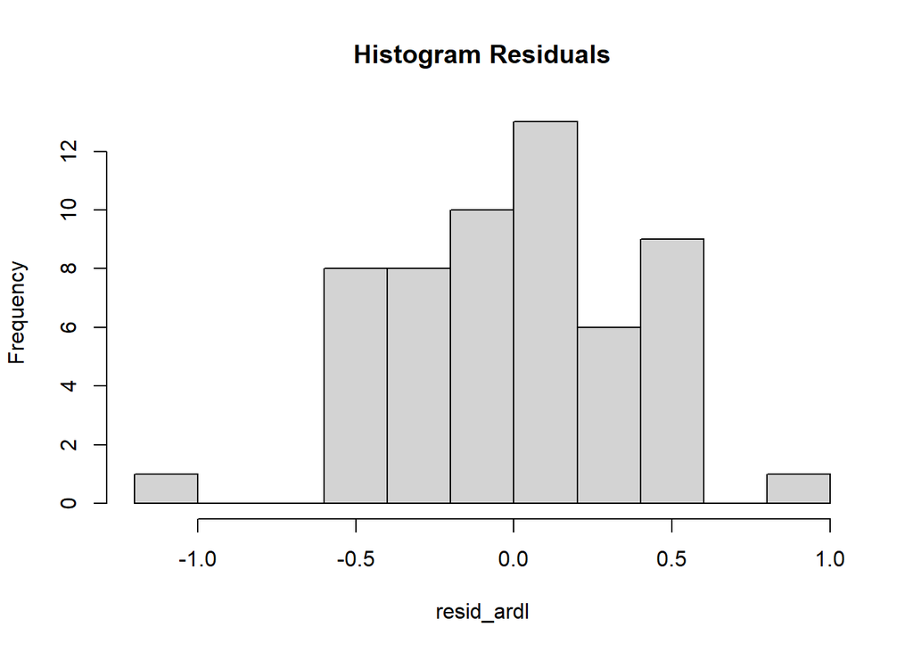

```r
hist(resid_ardl, breaks=10, main="Histogram Residuals")
```

```r
## 3. Homoskedastisitas
bptest(model_ardl$model)                              # Breusch–Pagan
```

```
##
##  studentized Breusch-Pagan test
##
## data:  model_ardl$model
## BP = 13.511, df = 3, p-value = 0.003653
```

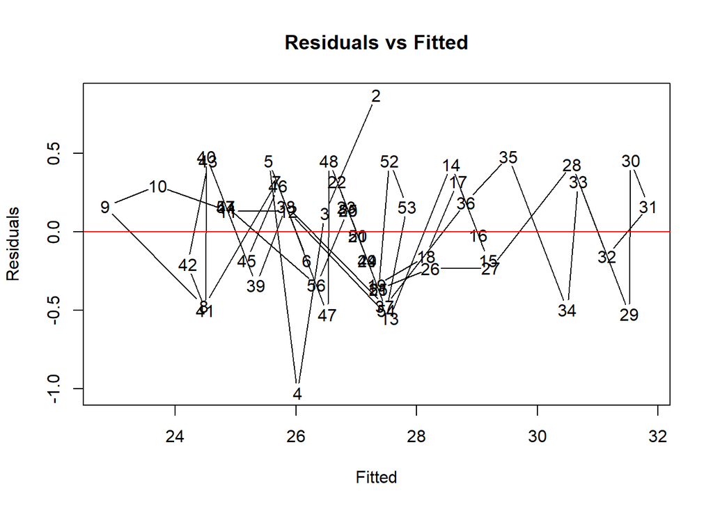

```r
plot(fitted(model_ardl$model), resid_ardl,
     main="Residuals vs Fitted",
     xlab="Fitted", ylab="Residuals")
abline(h=0, col="red")
```

```r
## 4. Nilai harapan sisaan
mean(resid_ardl)   # harus mendekati 0
```

```
## [1] -1.8581e-17
```

1. Autokorelasi (Breusch–Godfrey Test) LM test = 24.651, p-value = 0.00016 (< 0.05) Artinya: terdapat autokorelasi signifikan pada sisaan sampai lag 5.
2. Normalitas Residu Shapiro–Wilk: p = 0.074 (> 0.05) → gagal tolak H₀ → residu mendekati normal. Jarque–Bera: p = 0.672 (> 0.05) → sama, mendukung residu berdistribusi normal. Implikasi: asumsi normalitas terpenuhi, sehingga estimasi parameter via OLS masih valid.
3. Homoskedastisitas (Breusch–Pagan Test) BP = 13.511, p = 0.0036 (< 0.05) Artinya: terdapat heteroskedastisitas signifikan pada sisaan. Implikasi: varian sisaan tidak konstan → bisa menyebabkan standard error bias.
4. Ekspektasi Residu Mean residu ≈ -1.85e-17 (sangat dekat 0). Implikasi: asumsi E[εₜ] = 0 terpenuhi.

Evaluasi Model Normalitas residu terpenuhi (Shapiro–Wilk, Jarque–Bera). Ada autokorelasi (BG test signifikan) → mungkin perlu penambahan lag (p/q) atau modifikasi model. Ada heteroskedastisitas (BP test signifikan) → gunakan robust SE agar inference tetap valid. Ekspektasi residu = 0 sesuai asumsi OLS. Kesimpulannya: Model ARDL sudah cukup baik dari sisi distribusi error, tetapi belum sempurna karena masih ada masalah autokorelasi dan heteroskedastisitas.

## Plot AQI Train vs Test

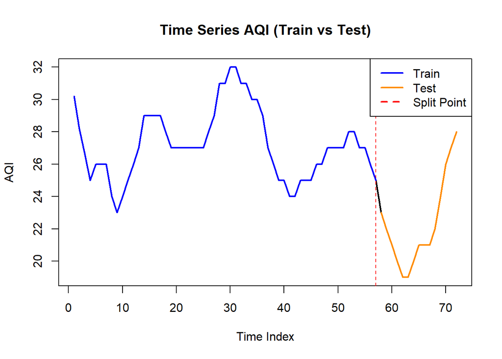

```r
plot(data$AQI, type="l", col="black", lwd=2,
     main="Time Series AQI (Train vs Test)",
     xlab="Time Index", ylab="AQI")

abline(v = n_train, col="red", lty=2)   # garis pemisah
lines(1:n_train, train$AQI, col="blue", lwd=2)
lines((n_train+1):n, test$AQI, col="darkorange", lwd=2)

legend("topright", legend=c("Train","Test","Split Point"),
       col=c("blue","darkorange","red"), lty=c(1,1,2), lwd=2)
```

## Plot O3 Train vs Test

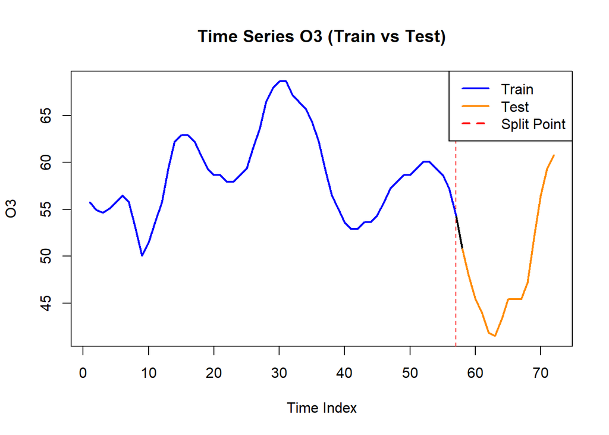

```r
plot(data$O3, type="l", col="black", lwd=2,
     main="Time Series O3 (Train vs Test)",
     xlab="Time Index", ylab="O3")

abline(v = n_train, col="red", lty=2)
lines(1:n_train, train$O3, col="blue", lwd=2)
lines((n_train+1):n, test$O3, col="darkorange", lwd=2)

legend("topright", legend=c("Train","Test","Split Point"),
       col=c("blue","darkorange","red"), lty=c(1,1,2), lwd=2)
```

# Model Koyck

```r
model.koyck <- koyckDlm(x = train$O3, y = train$AQI)
summary(model.koyck)
```

```
##
## Call:
## "Y ~ (Intercept) + Y.1 + X.t"
##
## Residuals:
##       Min        1Q    Median        3Q       Max
## -1.127670 -0.301407  0.001002  0.262601  1.103471
##
## Coefficients:
##             Estimate Std. Error t value Pr(>|t|)
## (Intercept)  0.54798    0.92878   0.590    0.558
## Y.1          0.41955    0.08223   5.102 4.63e-06 ***
## X.t          0.25830    0.04107   6.289 6.25e-08 ***
## ---
## Signif. codes:  0 '***' 0.001 '**' 0.01 '*' 0.05 '.' 0.1 ' ' 1
##
## Residual standard error: 0.5053 on 53 degrees of freedom
## Multiple R-Squared: 0.9463,  Adjusted R-squared: 0.9443
## Wald test: 423.7 on 2 and 53 DF,  p-value: < 2.2e-16
##
## Diagnostic tests:
## NULL
##
##                             alpha      beta       phi
## Geometric coefficients:  0.944071 0.2582957 0.4195528
```

```r
AIC(model.koyck)
```

```
## [1] 87.39413
```

```r
BIC(model.koyck)
```

```
## [1] 95.49554
```

Intercept: 0.54798 (tidak signifikan, p = 0.558). Y.1 (lag AQI): 0.41955, signifikan (p < 0.001). → Menunjukkan adanya efek inersia: nilai AQI saat ini sangat dipengaruhi oleh nilai AQI periode sebelumnya. X.t (O₃): 0.25830, signifikan (p < 0.001). → Peningkatan O₃ mendorong kenaikan AQI secara signifikan. R² = 0.9463 → Model menjelaskan ±94.6% variasi AQI. Wald test (p < 2.2e-16) → Model secara keseluruhan signifikan.

AIC = 87.39, BIC = 95.50 → Dipakai untuk perbandingan dengan model ARDL.

Kesimpulan Model Koyck ini menunjukkan bahwa O₃ adalah prediktor signifikan terhadap AQI baik secara langsung maupun jangka panjang, dan AQI sendiri memiliki sifat autoregresif (dipengaruhi kondisi sebelumnya). Model sudah cukup kuat (R² tinggi), namun nanti perlu dibandingkan dengan ARDL untuk melihat apakah pemilihan lag eksplisit (p, q) bisa mengurangi masalah autokorelasi/heteroskedastisitas.

Model
$$y_t=0.54798+0.25830X_t+0.41955Y_{t-1}$$
## Peramalan dan Akurasi

```r
library(dLagM)
library(Metrics)
h <- nrow(test)
fore.koyck <- forecast(model = model.koyck, x = test$O3, h = h)
fore.koyck
```

```
## $forecasts
##  [1] 24.15387 23.05989 21.95429 21.12094 20.21706 19.74546 20.00947 20.67448
##  [9] 20.95348 21.07054 21.58152 23.08914 24.83015 26.29958 27.28558
##
## $call
## forecast.koyckDlm(model = model.koyck, x = test$O3, h = h)
##
## attr(,"class")
## [1] "forecast.koyckDlm" "dLagM"
```

```r
rmse_koyck <- rmse(test$AQI, as.numeric(fore.koyck$forecasts))
mae_koyck  <- mae (test$AQI, as.numeric(fore.koyck$forecasts))
mape_koyck <- mape(test$AQI, as.numeric(fore.koyck$forecasts))
c(RMSE = rmse_koyck, MAE = mae_koyck, MAPE = mape_koyck)
```

```
##       RMSE        MAE       MAPE
## 0.82245296 0.70783947 0.03187326
```

```r
GoF(model.koyck) #Akurasi data training
```

```
##              n       MAE         MPE       MAPE      sMAPE      MASE       MSE
## model.koyck 56 0.3849916 -0.00049635 0.01435646 0.01433475 0.6015494 0.2416839
##                  MRAE    GMRAE
## model.koyck 589435374 7663.933
```

# Pemodelan Lag

```r
# DL model dengan q = 2
model.dlm <- dlm(x = train$O3, y = train$AQI, q = 2)
summary(model.dlm)
```

```
##
## Call:
## lm(formula = model.formula, data = design)
##
## Residuals:
##      Min       1Q   Median       3Q      Max
## -0.45678 -0.35809 -0.02571  0.25176  1.40513
##
## Coefficients:
##              Estimate Std. Error t value Pr(>|t|)
## (Intercept) -0.052782   0.689979  -0.076    0.939
## x.t          0.476379   0.053816   8.852 6.95e-12 ***
## x.1         -0.005756   0.099095  -0.058    0.954
## x.2         -0.008392   0.055411  -0.151    0.880
## ---
## Signif. codes:  0 '***' 0.001 '**' 0.01 '*' 0.05 '.' 0.1 ' ' 1
##
## Residual standard error: 0.3501 on 51 degrees of freedom
## Multiple R-squared:  0.9751, Adjusted R-squared:  0.9736
## F-statistic:   666 on 3 and 51 DF,  p-value: < 2.2e-16
##
## AIC and BIC values for the model:
##       AIC      BIC
## 1 46.4728 56.50947
```

```r
AIC(model.dlm)
```

```
## [1] 46.4728
```

```r
BIC(model.dlm)
```

```
## [1] 56.50947
```

```r
# cari lag optimum q ∈ [1,10] berdasarkan AIC
finiteDLMauto(
  formula    = AQI ~ O3,
  data       = data.frame(train),
  q.min      = 1,
  q.max      = 10,
  model.type = "dlm",
  error.type = "AIC",
  trace      = TRUE
)
```

```
##    q - k    MASE      AIC      BIC     GMRAE   MBRAE R.Adj.Sq  Ljung-Box
## 10    10 0.35051 22.97129 47.02321 14499.820 0.49589  0.98302 0.35474502
## 3      3 0.39875 27.06744 39.00134  6447.089 0.49480  0.98198 0.10728965
## 5      5 0.38245 27.17252 42.78247  7468.898 0.49506  0.98252 0.17930776
## 4      4 0.39892 27.90158 41.69362  8742.382 0.49838  0.98187 0.16589034
## 9      9 0.38342 29.59952 52.05393 11575.966 0.50164  0.98105 0.83879203
## 6      6 0.38046 29.81810 47.20453  6019.920 0.48473  0.98200 0.19113496
## 7      7 0.39444 30.91101 50.03124  7435.980 0.49025  0.98199 0.27024407
## 8      8 0.40121 31.26668 52.07671 10182.702 0.51165  0.98151 0.41738843
## 2      2 0.42869 46.47280 56.50947  6714.446 0.48891  0.97365 0.08751929
## 1      1 0.50971 90.38861 98.49001  6923.684 0.40817  0.94126 0.16081431
```

```r
# DL model dengan lag optimum
model.dlm.opt <- dlm(x = train$O3, y = train$AQI, q = 10)
summary(model.dlm.opt)
```

```
##
## Call:
## lm(formula = model.formula, data = design)
##
## Residuals:
##     Min      1Q  Median      3Q     Max
## -0.5204 -0.1663  0.0356  0.1624  0.5130
##
## Coefficients:
##              Estimate Std. Error t value Pr(>|t|)
## (Intercept) -0.294780   0.931786  -0.316  0.75361
## x.t          0.405638   0.063702   6.368 2.54e-07 ***
## x.1          0.159000   0.133129   1.194  0.24038
## x.2         -0.052741   0.126788  -0.416  0.67997
## x.3         -0.148621   0.121282  -1.225  0.22860
## x.4          0.143544   0.124404   1.154  0.25638
## x.5         -0.007047   0.123348  -0.057  0.95476
## x.6         -0.127683   0.123191  -1.036  0.30709
## x.7          0.287823   0.121937   2.360  0.02396 *
## x.8         -0.399437   0.121443  -3.289  0.00230 **
## x.9          0.304147   0.103813   2.930  0.00594 **
## x.10        -0.098958   0.048025  -2.061  0.04684 *
## ---
## Signif. codes:  0 '***' 0.001 '**' 0.01 '*' 0.05 '.' 0.1 ' ' 1
##
## Residual standard error: 0.2715 on 35 degrees of freedom
## Multiple R-squared:  0.9871, Adjusted R-squared:  0.983
## F-statistic: 243.1 on 11 and 35 DF,  p-value: < 2.2e-16
##
## AIC and BIC values for the model:
##        AIC      BIC
## 1 22.97129 47.02321
```

```r
AIC(model.dlm.opt); BIC(model.dlm.opt)
```

```
## [1] 22.97129
```

```
## [1] 47.02321
```

```r
# ARDL dengan interface x–y
model.ardl <- ardlDlm(x = train$O3, y = train$AQI, p = 1, q = 1)
summary(model.ardl)
```

```
##
## Time series regression with "ts" data:
## Start = 2, End = 57
##
## Call:
## dynlm(formula = as.formula(model.text), data = data, start = 1)
##
## Residuals:
##     Min      1Q  Median      3Q     Max
## -1.0261 -0.2582  0.1254  0.2988  0.8683
##
## Coefficients:
##             Estimate Std. Error t value Pr(>|t|)
## (Intercept) -0.14906    0.67926  -0.219    0.827
## X.t          0.47821    0.03429  13.946  < 2e-16 ***
## X.1         -0.22331    0.04692  -4.759 1.59e-05 ***
## Y.1          0.45264    0.06656   6.801 1.03e-08 ***
## ---
## Signif. codes:  0 '***' 0.001 '**' 0.01 '*' 0.05 '.' 0.1 ' ' 1
##
## Residual standard error: 0.3812 on 52 degrees of freedom
## Multiple R-squared:   0.97,  Adjusted R-squared:  0.9683
## F-statistic: 561.2 on 3 and 52 DF,  p-value: < 2.2e-16
```

```r
AIC(model.ardl)
```

```
## [1] 56.75817
```

```r
BIC(model.ardl)
```

```
## [1] 66.88493
```

```r
# ARDL dengan interface formula + data frame
model.ardl <- ardlDlm(formula = AQI ~ O3, data = train, p = 1, q = 1)
summary(model.ardl)
```

```
##
## Time series regression with "ts" data:
## Start = 2, End = 57
##
## Call:
## dynlm(formula = as.formula(model.text), data = data)
##
## Residuals:
##     Min      1Q  Median      3Q     Max
## -1.0261 -0.2582  0.1254  0.2988  0.8683
##
## Coefficients:
##             Estimate Std. Error t value Pr(>|t|)
## (Intercept) -0.14906    0.67926  -0.219    0.827
## O3.t         0.47821    0.03429  13.946  < 2e-16 ***
## O3.1        -0.22331    0.04692  -4.759 1.59e-05 ***
## AQI.1        0.45264    0.06656   6.801 1.03e-08 ***
## ---
## Signif. codes:  0 '***' 0.001 '**' 0.01 '*' 0.05 '.' 0.1 ' ' 1
##
## Residual standard error: 0.3812 on 52 degrees of freedom
## Multiple R-squared:   0.97,  Adjusted R-squared:  0.9683
## F-statistic: 561.2 on 3 and 52 DF,  p-value: < 2.2e-16
```

```r
AIC(model.ardl)
```

```
## [1] 56.75817
```

```r
BIC(model.ardl)
```

```
## [1] 66.88493
```

## Peramalan dan Akurasi

```r
# Peramalan & akurasi untuk model terpilih
h <- nrow(test)
fore.opt <- forecast(model = model.dlm.opt, x = test$O3, h = h)

library(Metrics)
rmse_opt <- rmse(test$AQI, as.numeric(fore.opt$forecasts))
mae_opt  <- mae (test$AQI, as.numeric(fore.opt$forecasts))
mape_opt <- mape(test$AQI, as.numeric(fore.opt$forecasts))

c(RMSE = rmse_opt, MAE = mae_opt, MAPE = mape_opt)
```

```
##       RMSE        MAE       MAPE
## 0.33666087 0.28577674 0.01274404
```

Model DL dengan lag optimum q=10 (berdasarkan AIC) tidak hanya pas di data training, tetapi juga memberikan peramalan yang sangat baik di data testing. Dengan MAPE < 5%, model ini bisa dikategorikan sebagai model dengan akurasi sangat tinggi (Lewis, 1982). Hal ini mengindikasikan bahwa $O_3$ dengan lag sampai 10 periode sangat efektif menjelaskan dinamika AQI di New Delhi.

# Pemodelan DLM & ARDL dengan Library `dynlm`

```r
# sama dengan DLM q = 1
cons_lm1 <- dynlm(AQI ~ O3 + L(O3), data = train.ts)
# sama dengan ARDL p = 1, q = 0
cons_lm2 <- dynlm(AQI ~ O3 + L(AQI), data = train.ts)
# sama dengan ARDL p = 1, q = 1
cons_lm3 <- dynlm(AQI ~ O3 + L(O3) + L(AQI), data = train.ts)
# sama dengan DLM q = 2
cons_lm4 <- dynlm(AQI ~ O3 + L(O3) + L(O3, 2), data = train.ts)
```

## Ringkasan Model

```r
summary(cons_lm1)
```

```
##
## Time series regression with "ts" data:
## Start = 2, End = 57
##
## Call:
## dynlm(formula = AQI ~ O3 + L(O3), data = train.ts)
##
## Residuals:
##      Min       1Q   Median       3Q      Max
## -0.51031 -0.40204 -0.09081  0.21207  2.78493
##
## Coefficients:
##             Estimate Std. Error t value Pr(>|t|)
## (Intercept)  0.46584    0.91660   0.508    0.613
## O3           0.46014    0.04655   9.886 1.26e-13 ***
## L(O3)       -0.00586    0.04676  -0.125    0.901
## ---
## Signif. codes:  0 '***' 0.001 '**' 0.01 '*' 0.05 '.' 0.1 ' ' 1
##
## Residual standard error: 0.519 on 53 degrees of freedom
## Multiple R-squared:  0.9434, Adjusted R-squared:  0.9413
## F-statistic: 441.6 on 2 and 53 DF,  p-value: < 2.2e-16
```

```r
summary(cons_lm2)
```

```
##
## Time series regression with "ts" data:
## Start = 2, End = 57
##
## Call:
## dynlm(formula = AQI ~ O3 + L(AQI), data = train.ts)
##
## Residuals:
##      Min       1Q   Median       3Q      Max
## -0.78961 -0.30739 -0.06053  0.20120  1.70996
##
## Coefficients:
##             Estimate Std. Error t value Pr(>|t|)
## (Intercept) -0.27989    0.80546  -0.347 0.729596
## O3           0.35714    0.02728  13.091  < 2e-16 ***
## L(AQI)       0.23682    0.05781   4.096 0.000144 ***
## ---
## Signif. codes:  0 '***' 0.001 '**' 0.01 '*' 0.05 '.' 0.1 ' ' 1
##
## Residual standard error: 0.4524 on 53 degrees of freedom
## Multiple R-squared:  0.957,  Adjusted R-squared:  0.9554
## F-statistic: 589.6 on 2 and 53 DF,  p-value: < 2.2e-16
```

```r
summary(cons_lm3)
```

```
##
## Time series regression with "ts" data:
## Start = 2, End = 57
##
## Call:
## dynlm(formula = AQI ~ O3 + L(O3) + L(AQI), data = train.ts)
##
## Residuals:
##     Min      1Q  Median      3Q     Max
## -1.0261 -0.2582  0.1254  0.2988  0.8683
##
## Coefficients:
##             Estimate Std. Error t value Pr(>|t|)
## (Intercept) -0.14906    0.67926  -0.219    0.827
## O3           0.47821    0.03429  13.946  < 2e-16 ***
## L(O3)       -0.22331    0.04692  -4.759 1.59e-05 ***
## L(AQI)       0.45264    0.06656   6.801 1.03e-08 ***
## ---
## Signif. codes:  0 '***' 0.001 '**' 0.01 '*' 0.05 '.' 0.1 ' ' 1
##
## Residual standard error: 0.3812 on 52 degrees of freedom
## Multiple R-squared:   0.97,  Adjusted R-squared:  0.9683
## F-statistic: 561.2 on 3 and 52 DF,  p-value: < 2.2e-16
```

```r
summary(cons_lm4)
```

```
##
## Time series regression with "ts" data:
## Start = 3, End = 57
##
## Call:
## dynlm(formula = AQI ~ O3 + L(O3) + L(O3, 2), data = train.ts)
##
## Residuals:
##      Min       1Q   Median       3Q      Max
## -0.45678 -0.35809 -0.02571  0.25176  1.40513
##
## Coefficients:
##              Estimate Std. Error t value Pr(>|t|)
## (Intercept) -0.052782   0.689979  -0.076    0.939
## O3           0.476379   0.053816   8.852 6.95e-12 ***
## L(O3)       -0.005756   0.099095  -0.058    0.954
## L(O3, 2)    -0.008392   0.055411  -0.151    0.880
## ---
## Signif. codes:  0 '***' 0.001 '**' 0.01 '*' 0.05 '.' 0.1 ' ' 1
##
## Residual standard error: 0.3501 on 51 degrees of freedom
## Multiple R-squared:  0.9751, Adjusted R-squared:  0.9736
## F-statistic:   666 on 3 and 51 DF,  p-value: < 2.2e-16
```

## SSE

```r
deviance(cons_lm1)
```

```
## [1] 14.27771
```

```r
deviance(cons_lm2)
```

```
## [1] 10.84775
```

```r
deviance(cons_lm3)
```

```
## [1] 7.556756
```

```r
deviance(cons_lm4)
```

```
## [1] 6.250103
```

## Uji Diagnostik

```r
encomptest(cons_lm1, cons_lm2)
```

```
## Encompassing test
##
## Model 1: AQI ~ O3 + L(O3)
## Model 2: AQI ~ O3 + L(AQI)
## Model E: AQI ~ O3 + L(O3) + L(AQI)
##           Res.Df Df      F    Pr(>F)
## M1 vs. ME     52 -1 46.249 1.029e-08 ***
## M2 vs. ME     52 -1 22.646 1.592e-05 ***
## ---
## Signif. codes:  0 '***' 0.001 '**' 0.01 '*' 0.05 '.' 0.1 ' ' 1
```

## Autokorelasi

```r
# Durbin–Watson
dwtest(cons_lm1); dwtest(cons_lm2); dwtest(cons_lm3); dwtest(cons_lm4)
```

```
##
##  Durbin-Watson test
##
## data:  cons_lm1
## DW = 1.0904, p-value = 5.766e-05
## alternative hypothesis: true autocorrelation is greater than 0
```

```
##
##  Durbin-Watson test
##
## data:  cons_lm2
## DW = 1.687, p-value = 0.07733
## alternative hypothesis: true autocorrelation is greater than 0
```

```
##
##  Durbin-Watson test
##
## data:  cons_lm3
## DW = 2.7592, p-value = 0.9954
## alternative hypothesis: true autocorrelation is greater than 0
```

```
##
##  Durbin-Watson test
##
## data:  cons_lm4
## DW = 2.1325, p-value = 0.5819
## alternative hypothesis: true autocorrelation is greater than 0
```

## Heteroskedastisitas

```r
# Breusch–Pagan
bptest(cons_lm1); bptest(cons_lm2); bptest(cons_lm3); bptest(cons_lm4)
```

```
##
##  studentized Breusch-Pagan test
##
## data:  cons_lm1
## BP = 1.2214, df = 2, p-value = 0.543
```

```
##
##  studentized Breusch-Pagan test
##
## data:  cons_lm2
## BP = 22.69, df = 2, p-value = 1.183e-05
```

```
##
##  studentized Breusch-Pagan test
##
## data:  cons_lm3
## BP = 13.511, df = 3, p-value = 0.003653
```

```
##
##  studentized Breusch-Pagan test
##
## data:  cons_lm4
## BP = 0.93628, df = 3, p-value = 0.8167
```

## Kenormalan Residu

```r
shapiro.test(residuals(cons_lm1))
```

```
##
##  Shapiro-Wilk normality test
##
## data:  residuals(cons_lm1)
## W = 0.69289, p-value = 1.56e-09
```

```r
shapiro.test(residuals(cons_lm2))
```

```
##
##  Shapiro-Wilk normality test
##
## data:  residuals(cons_lm2)
## W = 0.93188, p-value = 0.003549
```

```r
shapiro.test(residuals(cons_lm3))
```

```
##
##  Shapiro-Wilk normality test
##
## data:  residuals(cons_lm3)
## W = 0.96195, p-value = 0.07469
```

```r
shapiro.test(residuals(cons_lm4))
```

```
##
##  Shapiro-Wilk normality test
##
## data:  residuals(cons_lm4)
## W = 0.84042, p-value = 3.659e-06
```

## Forecast dan Akurasi

### Koyck

```r
model.koyck <- koyckDlm(x = train$O3, y = train$AQI)
```

### DLM q=1 dan q=2

```r
model.dlm1 <- dlm(x = train$O3, y = train$AQI, q = 1)
model.dlm2 <- dlm(x = train$O3, y = train$AQI, q = 2)
```

### ARDL p=1, q=1

```r
model.ardl <- ardlDlm(x = train$O3, y = train$AQI, p = 1, q = 1)
```

```r
library(dLagM)
# Pastikan model ARDL-nya dari FORMULA (biar konsisten dengan rule forecast ARDL)
model.ardl <- dLagM::ardlDlm(formula = AQI ~ O3, data = train, p = 1, q = 1)

# Horizon
h <- nrow(test)

# Siapkan X untuk forecast ARDL: 1 × h (satu prediktor O3)
Xtest_mat <- matrix(test$O3, nrow = 1, ncol = h, byrow = TRUE)  # <- penting: 1 x h

# Forecast
fore.ardl <- dLagM::forecast(model.ardl, x = Xtest_mat, h = h)

# Akurasi
library(Metrics)
yhat_ardl <- as.numeric(fore.ardl$forecasts)
c(
  RMSE = rmse(test$AQI, yhat_ardl),
  MAE  = mae (test$AQI, yhat_ardl),
  MAPE = mape(test$AQI, yhat_ardl)
)
```

```
##        RMSE         MAE        MAPE
## 0.190282399 0.156144581 0.006897306
```

### Forecast ke Test

```r
h <- nrow(test)
fore.koyck <- forecast(model.koyck, x = test$O3, h = h)
fore.dlm1  <- forecast(model.dlm1,  x = test$O3, h = h)
fore.dlm2  <- forecast(model.dlm2,  x = test$O3, h = h)
model.ardl <- ardlDlm(x = train$O3, y = train$AQI, p = 1, q = 1)
```

### Akurasi (MAPE/RMSE/MAE)

```r
mape.koyck <- mape(test$AQI, as.numeric(fore.koyck$forecasts))
mape.dlm1  <- mape(test$AQI, as.numeric(fore.dlm1$forecasts))
mape.dlm2  <- mape(test$AQI, as.numeric(fore.dlm2$forecasts))
mape.ardl  <- mape(test$AQI, as.numeric(fore.ardl$forecasts))

rmse.koyck <- rmse(test$AQI, as.numeric(fore.koyck$forecasts))
rmse.dlm1  <- rmse(test$AQI, as.numeric(fore.dlm1$forecasts))
rmse.dlm2  <- rmse(test$AQI, as.numeric(fore.dlm2$forecasts))
rmse.ardl  <- rmse(test$AQI, as.numeric(fore.ardl$forecasts))

mae.koyck  <- mae (test$AQI, as.numeric(fore.koyck$forecasts))
mae.dlm1   <- mae (test$AQI, as.numeric(fore.dlm1$forecasts))
mae.dlm2   <- mae (test$AQI, as.numeric(fore.dlm2$forecasts))
mae.ardl   <- mae (test$AQI, as.numeric(fore.ardl$forecasts))
```

### Perbandingan Model (MAPE)

```r
akurasi <- matrix(c(mape.koyck, mape.dlm1, mape.dlm2, mape.ardl))
rownames(akurasi) <- c("Koyck","DLM q=1","DLM q=2","ARDL p=1,q=1")
colnames(akurasi) <- "MAPE"
akurasi
```

```
##                     MAPE
## Koyck        0.031873255
## DLM q=1      0.010601766
## DLM q=2      0.006820359
## ARDL p=1,q=1 0.006897306
```

### Plot Prediksi vs Aktual (x-axis = indeks waktu test)

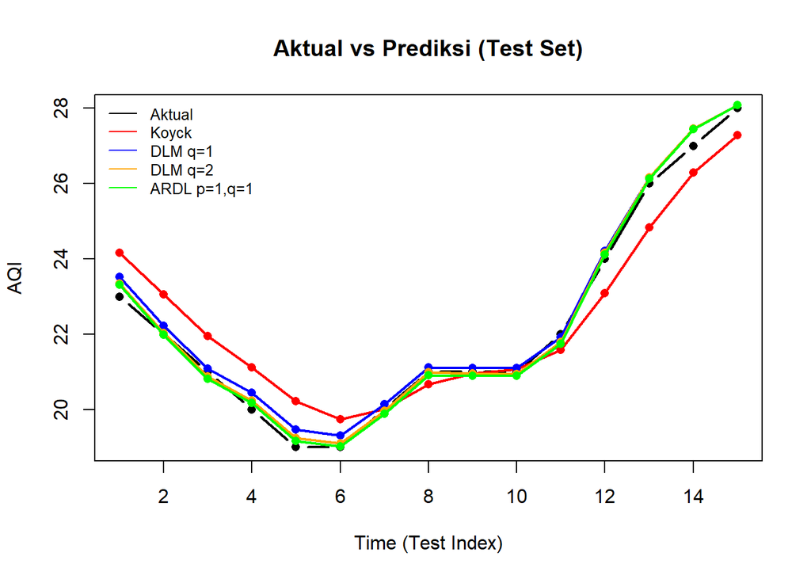

```r
par(mfrow = c(1,1))
tidx <- seq_len(nrow(test))  # indeks waktu test

plot(tidx, test$AQI, type="b", col="black", pch=16, lwd=2,
     xlab="Time (Test Index)", ylab="AQI",
     main="Aktual vs Prediksi (Test Set)")

lines(tidx, as.numeric(fore.koyck$forecasts), col="red",   lwd=2)
points(tidx, as.numeric(fore.koyck$forecasts), col="red",  pch=16)

lines(tidx, as.numeric(fore.dlm1$forecasts),  col="blue",  lwd=2)
points(tidx, as.numeric(fore.dlm1$forecasts), col="blue",  pch=16)

lines(tidx, as.numeric(fore.dlm2$forecasts),  col="orange",lwd=2)
points(tidx, as.numeric(fore.dlm2$forecasts), col="orange",pch=16)

lines(tidx, as.numeric(fore.ardl$forecasts),  col="green", lwd=2)
points(tidx, as.numeric(fore.ardl$forecasts), col="green", pch=16)

legend("topleft",
       c("Aktual","Koyck","DLM q=1","DLM q=2","ARDL p=1,q=1"),
       lty=1, col=c("black","red","blue","orange","green"), cex=0.8, bty="n")
```

```r
library(Metrics)

# hitung akurasi test untuk masing2 model
acc <- data.frame(
  Model = c("Koyck","DLM q=1","DLM q=2","ARDL p=1,q=1"),
  RMSE  = c(
    rmse(test$AQI, as.numeric(fore.koyck$forecasts)),
    rmse(test$AQI, as.numeric(fore.dlm1$forecasts)),
    rmse(test$AQI, as.numeric(fore.dlm2$forecasts)),
    rmse(test$AQI, as.numeric(fore.ardl$forecasts))
  ),
  MAE   = c(
    mae(test$AQI, as.numeric(fore.koyck$forecasts)),
    mae(test$AQI, as.numeric(fore.dlm1$forecasts)),
    mae(test$AQI, as.numeric(fore.dlm2$forecasts)),
    mae(test$AQI, as.numeric(fore.ardl$forecasts))
  ),
  MAPE  = c(
    mape(test$AQI, as.numeric(fore.koyck$forecasts)),
    mape(test$AQI, as.numeric(fore.dlm1$forecasts)),
    mape(test$AQI, as.numeric(fore.dlm2$forecasts)),
    mape(test$AQI, as.numeric(fore.ardl$forecasts))
  )
)

# urutkan dari yang terbaik (MAPE terkecil)
acc <- acc[order(acc$MAPE), ]
acc
```

```
##          Model      RMSE       MAE        MAPE
## 3      DLM q=2 0.1986852 0.1546344 0.006820359
## 4 ARDL p=1,q=1 0.1902824 0.1561446 0.006897306
## 2      DLM q=1 0.2783902 0.2312746 0.010601766
## 1        Koyck 0.8224530 0.7078395 0.031873255
```

```r
best_model_name <- acc$Model[1]
best_model_name
```

```
## [1] "DLM q=2"
```

Model terbaik adalah DLM q=2 karena memiliki MAPE terkecil

## Uji Asumsi

### Residual

```r
library(lmtest)
library(tseries)
resid_dlm2 <- residuals(model.dlm2)
```

```
##            1            2            3            4            5            6
##  1.405126485 -0.408161115  0.251173931 -0.081840606  0.269011029 -0.366171483
##            7            8            9           10           11           12
## -0.025707751  0.252349536  0.214374814  0.216530301 -0.456777099  0.218880999
##           13           14           15           16           17           18
## -0.075373212 -0.047247202  0.299487726 -0.023162794 -0.355932331 -0.035437289
##           19           20           21           22           23           24
## -0.051558641  0.283171631  0.279054950 -0.067679978 -0.404296377 -0.416376132
##           25           26           27           28           29           30
## -0.420222509  0.247204118 -0.399789758  0.291720324  0.307841695 -0.004690773
##           31           32           33           34           35           36
##  0.327810850 -0.347580285  0.323765905  0.331730455 -0.329691944 -0.001233860
##           37           38           39           40           41           42
## -0.360243294  0.288979214 -0.390526217 -0.406647546  0.246617526  0.250734207
##           43           44           45           46           47           48
## -0.083996550  0.238653976 -0.428576478  0.250928956 -0.073682302 -0.063563297
##           49           50           51           52           53           54
## -0.398294054  0.265089553  0.275208572 -0.378056015 -0.041439622 -0.370093433
##           55
## -0.021396805
```

### Autokorelasi

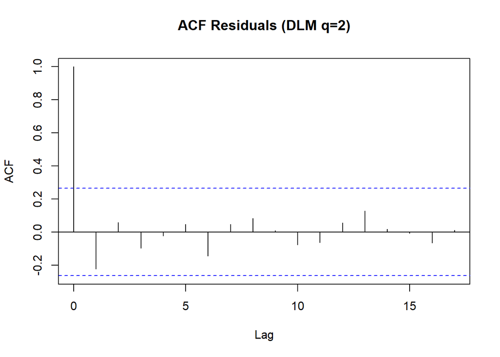

```r
acf(resid_dlm2, main="ACF Residuals (DLM q=2)")  # plot ACF
```

```r
dwtest(model.dlm2$model)                         # Durbin–Watson test
```

```
##
##  Durbin-Watson test
##
## data:  model.dlm2$model
## DW = 2.1325, p-value = 0.5819
## alternative hypothesis: true autocorrelation is greater than 0
```

```r
bgtest(model.dlm2$model, order = 5)              # Breusch–Godfrey, lag 5
```

```
##
##  Breusch-Godfrey test for serial correlation of order up to 5
##
## data:  model.dlm2$model
## LM test = 3.5006, df = 5, p-value = 0.6233
```

### Normalitas

```r
shapiro.test(resid_dlm2)                         # Shapiro–Wilk
```

```
##
##  Shapiro-Wilk normality test
##
## data:  resid_dlm2
## W = 0.84042, p-value = 3.659e-06
```

```r
jarque.bera.test(resid_dlm2)                     # Jarque–Bera
```

```
##
##  Jarque Bera Test
##
## data:  resid_dlm2
## X-squared = 34.07, df = 2, p-value = 3.998e-08
```

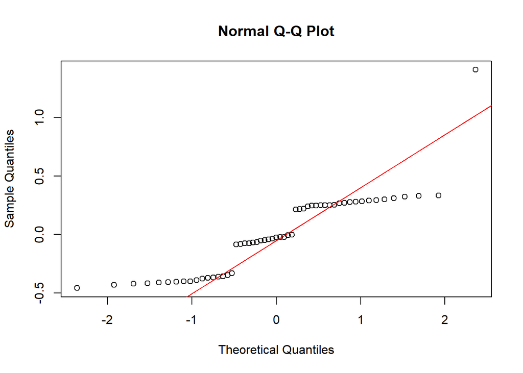

```r
qqnorm(resid_dlm2); qqline(resid_dlm2, col="red")
```

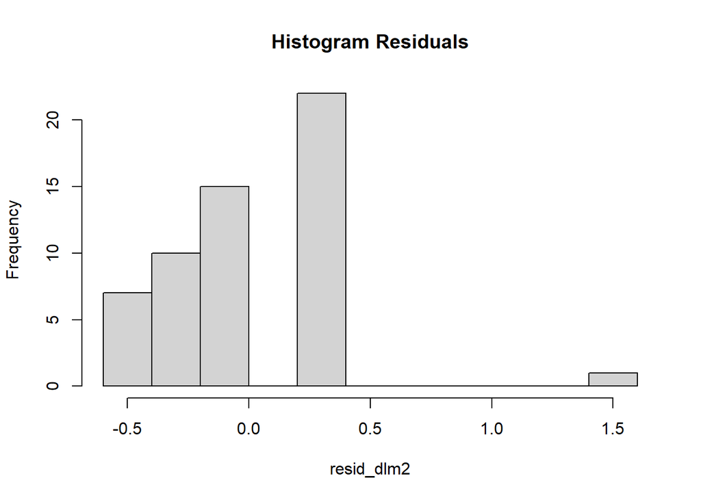

```r
hist(resid_dlm2, breaks=10, main="Histogram Residuals")
```

### Homoskedastisitas

```r
bptest(model.dlm2$model)                         # Breusch–Pagan
```

```
##
##  studentized Breusch-Pagan test
##
## data:  model.dlm2$model
## BP = 0.93628, df = 3, p-value = 0.8167
```

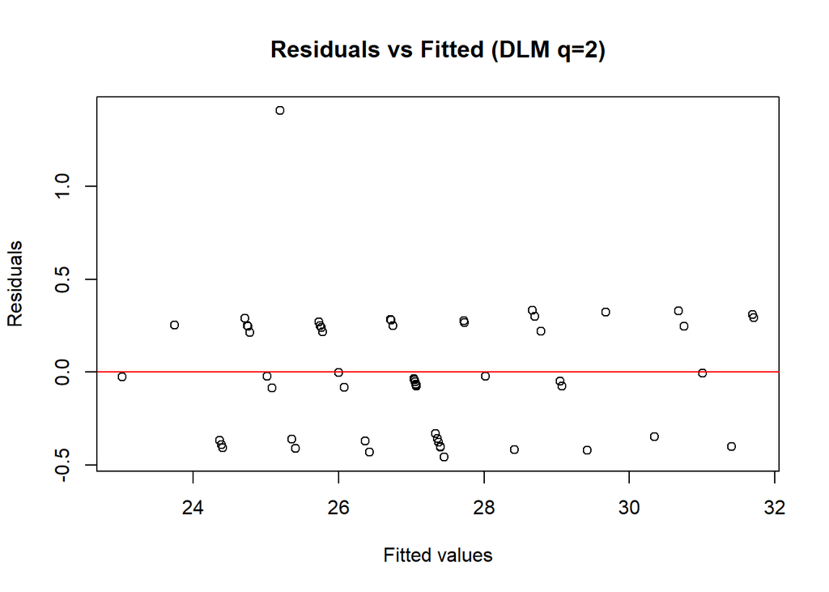

```r
plot(fitted(model.dlm2$model), resid_dlm2,
     main="Residuals vs Fitted (DLM q=2)",
     xlab="Fitted values", ylab="Residuals")
abline(h=0, col="red")
```

### Nilai Harapan Sisaan

```r
mean(resid_dlm2)   # harus mendekati 0
```

```
## [1] -1.966441e-17
```

Hasil uji asumsi terhadap model terbaik (DLM q=2) menunjukkan bahwa sebagian besar asumsi klasik terpenuhi. Uji autokorelasi (Durbin–Watson dan Breusch–Godfrey) memberikan p-value > 0,05, sehingga dapat disimpulkan tidak terdapat autokorelasi pada residu. Uji Breusch–Pagan juga menghasilkan p-value > 0,05 yang menandakan varians sisaan homogen (tidak terjadi heteroskedastisitas). Selain itu, rata-rata residu mendekati nol sesuai asumsi ekspektasi error. Namun, uji normalitas (Shapiro–Wilk dan Jarque–Bera) menunjukkan p-value < 0,05, sehingga residu tidak berdistribusi normal. Walaupun demikian, mengingat jumlah data relatif besar, pelanggaran normalitas ini tidak terlalu mengganggu validitas estimasi parameter karena estimator OLS tetap konsisten. Dengan demikian, model DLM q=2 masih layak digunakan sebagai model terbaik dalam memprediksi AQI berdasarkan konsentrasi O₃.